# Analyzing Individual BGG Users

Phil Henrickson

2022-01-02

# **SnowyAshton’s** BoardGameGeek Collection

This notebook contains a set of analyses for the selected user’s boardgamegeek collection. The bulk of the analysis is focused on building a user-specific predictive model to predict the games that SnowyAshton is likely to own. This enables to ask questions like, based on the games the user currently owns, what games are a good fit for their collection? What upcoming games are they likely to purchase?

This analysis is based on data from BoardGameGeek that was last updated on **2021-12-20.**

# 1 Collection Overview

We can look at a basic description of the number of games that the user owns, has rated, has previously owned, etc.

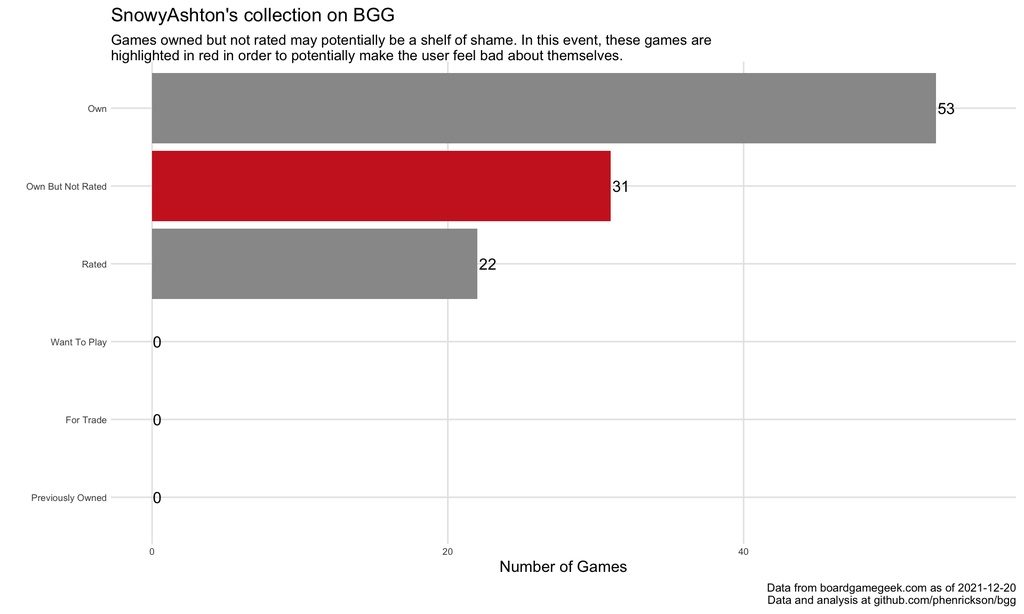

What years has the user owned/rated games from? While we can’t see when a user added or removed a game from their collection, we can look at their collection by the years in which their games were published.

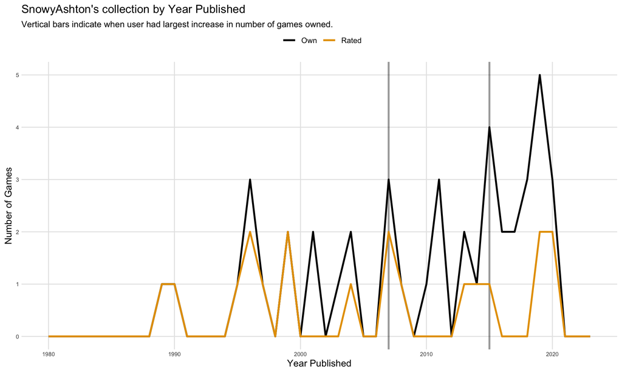

## 1.1 What types of games does SnowyAshton own?

We can look at the most frequent types of categories, mechanics, designers, and artists that appear in a user’s collection.

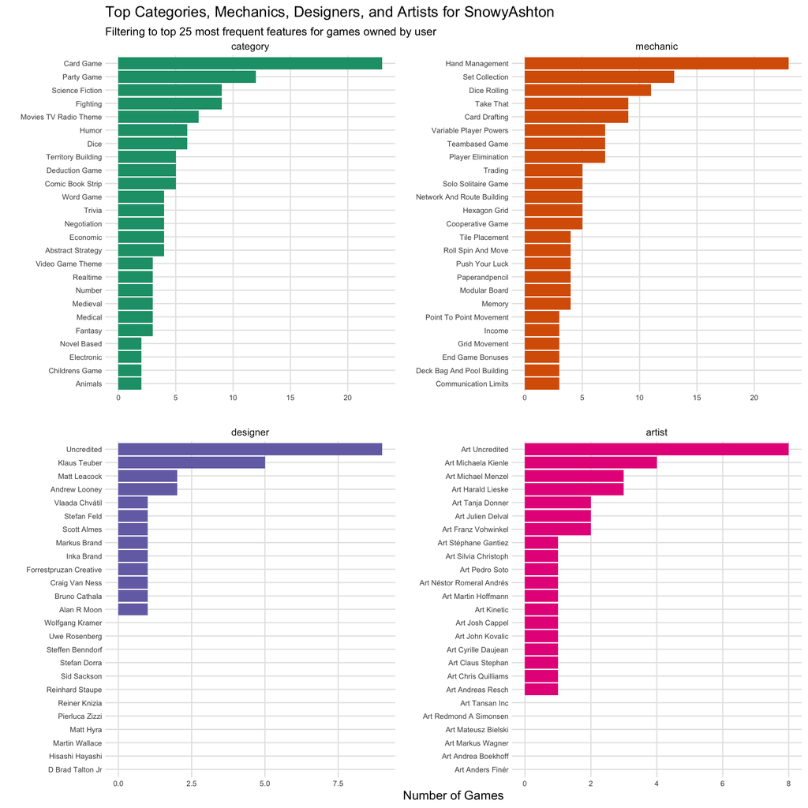

# 2 Modeling **SnowyAshton’s** Collection

| username | dataset | period | games_owned | games_rated | games_played |
| --- | --- | --- | --- | --- | --- |
| SnowyAshton | training | published before 2020 | 49 | 19 | 49 |
| SnowyAshton | test | published 2020 or later | 3 | 2 | 3 |

There are two main (binary) outcomes we will be modeling for the user.

The first, **own** refers to whether the user currently lists a game as owned in their collection. The second, **played** refers to whether the user currently owns, has rated, or previously owned a game. This means the latter will generally have a larger list of games, but may still be a useful category to examine for people who play lots of games without necessarily owning them.

We will train predictive models to learn the probability that the user will own or play individual games based on their features.

## 2.1 Coefficients for SnowyAshton

We can examine coefficients from the trained modes, which are penalized logistic regressions fit to our two main outcomes. Positive values indicate that a feature increases a user’s probabilility of owning/rating a game, while negative values indicate a feature decreases the probability.

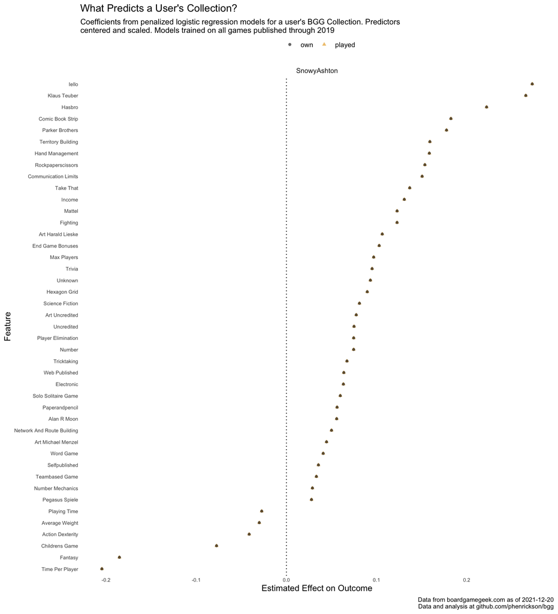

## 2.2 Visualizing Predictors for SnowyAshton’s Collection

Why did the model identify these features? We can make density plots of the important features for predicting whether the user owned a game. Blue indicates the density for games owned by the user, while grey indicates the density for games not owned by the user.

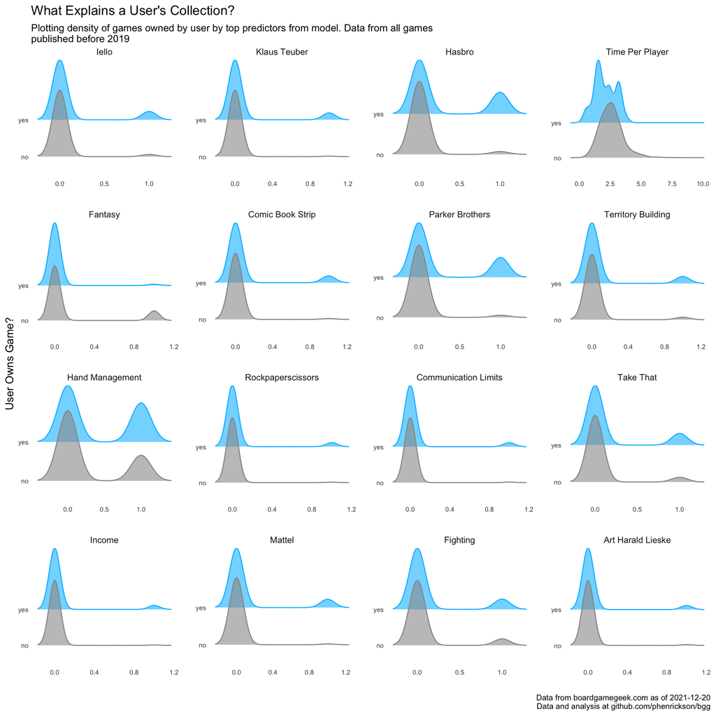

Binary predictors can be difficult to see with this visualization, so we can also directly examine the percentage of games in a user’s collection with a predictor vs the percentage of all games with that predictor.

| username | Feature | % of Games with Feature In_Collection | % of Games with Feature All_Games | Ratio |
| --- | --- | --- | --- | --- |
| SnowyAshton | Unknown | 16.3% | 1.4% | 11.6 |
| SnowyAshton | Mattel | 12.2% | 1.2% | 10.1 |
| SnowyAshton | Parker Brothers | 26.5% | 2.8% | 9.4 |
| SnowyAshton | Income | 6.1% | 0.7% | 8.7 |
| SnowyAshton | Rockpaperscissors | 6.1% | 0.8% | 7.9 |
| SnowyAshton | Comic Book Strip | 10.2% | 1.3% | 7.7 |
| SnowyAshton | Hasbro | 28.6% | 3.8% | 7.6 |
| SnowyAshton | Number | 6.1% | 0.9% | 6.9 |
| SnowyAshton | Communication Limits | 6.1% | 1.0% | 6.3 |
| SnowyAshton | End Game Bonuses | 6.1% | 1.3% | 4.8 |
| SnowyAshton | Electronic | 4.1% | 0.9% | 4.7 |
| SnowyAshton | Trivia | 8.2% | 1.8% | 4.6 |
| SnowyAshton | Iello | 12.2% | 3.1% | 3.9 |
| SnowyAshton | Web Published | 6.1% | 1.6% | 3.8 |
| SnowyAshton | Tricktaking | 6.1% | 1.7% | 3.7 |
| SnowyAshton | Player Elimination | 12.2% | 4.0% | 3.1 |
| SnowyAshton | Territory Building | 10.2% | 3.6% | 2.8 |
| SnowyAshton | Take That | 16.3% | 6.6% | 2.5 |
| SnowyAshton | Science Fiction | 16.3% | 8.7% | 1.9 |
| SnowyAshton | Solo Solitaire Game | 10.2% | 5.9% | 1.7 |
| SnowyAshton | Fighting | 14.3% | 9.1% | 1.6 |
| SnowyAshton | Hand Management | 40.8% | 26.7% | 1.5 |
| SnowyAshton | Hexagon Grid | 10.2% | 6.7% | 1.5 |
| SnowyAshton | Childrens Game | 4.1% | 5.7% | 0.7 |
| SnowyAshton | Fantasy | 2.0% | 14.9% | 0.1 |

# 3 Assess Model’s Performance on Training Set

Before predicting games in upcoming years, we can examine how well the model did and what games it liked in the training set. In this case, we used resampling techniques (cross validation) to ensure that the model had not seen a game before making its predictions.

## 3.1 Separation Plot

An easy way to examine the performance of classification model is to view a separation plot. We plot the predicted probabilities from the model for every game (from resampling) from lowest to highest. We then overlay a blue line for any game that the user does own. A good classifier is one that is able to *separate* the blue (games owned by the user) from the white (games not owned by the user), with most of the blue occurring at the highest probabilities (right side of the chart).

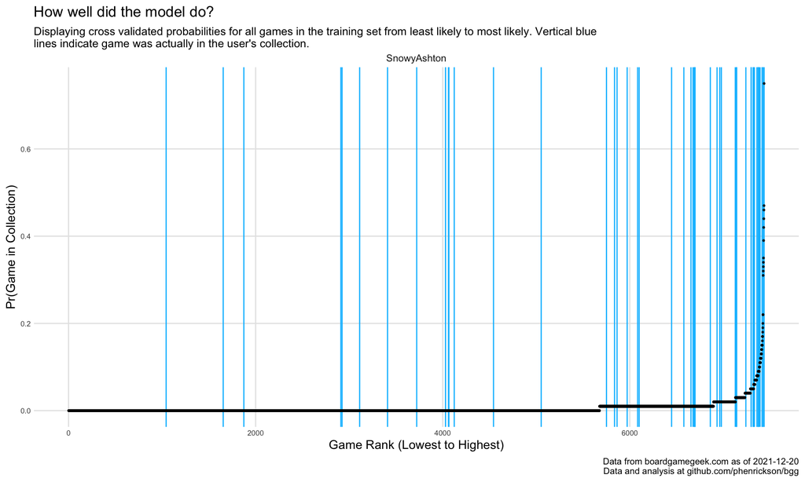

## 3.2 Top Games for **SnowyAshton** from Training Set

We can display this information in table form, displaying the 100 games with the highest probability of ownership, adding a blue line when the user does own the game.

| username | yearpublished | game_id | name | pred_played | pred_own | actual_played | actual_own |
| --- | --- | --- | --- | --- | --- | --- | --- |
| SnowyAshton | 1968 | 7262 | Top Trumps | 0.75 | 0.75 | 1 | 1 |
| SnowyAshton | 1900 | 2136 | Pachisi | 0.47 | 0.47 | 0 | 0 |
| SnowyAshton | 1933 | 1406 | Monopoly | 0.46 | 0.46 | 0 | 0 |
| SnowyAshton | 2016 | 167791 | Terraforming Mars | 0.44 | 0.44 | 0 | 0 |
| SnowyAshton | 1900 | 45 | Perudo | 0.42 | 0.42 | 0 | 0 |
| SnowyAshton | 1990 | 120 | Hoity Toity | 0.39 | 0.39 | 0 | 0 |
| SnowyAshton | 1986 | 4862 | Outburst! | 0.35 | 0.35 | 0 | 0 |
| SnowyAshton | 1995 | 13 | Catan | 0.34 | 0.34 | 1 | 1 |
| SnowyAshton | 1959 | 7688 | Memory | 0.33 | 0.33 | 0 | 0 |
| SnowyAshton | 1900 | 10799 | Old Maid | 0.32 | 0.32 | 0 | 0 |
| SnowyAshton | 2017 | 220308 | Gaia Project | 0.31 | 0.31 | 0 | 0 |
| SnowyAshton | 1900 | 2083 | Checkers | 0.22 | 0.22 | 0 | 0 |
| SnowyAshton | 2015 | 172242 | Exploding Kittens: NSFW Deck | 0.22 | 0.22 | 0 | 0 |
| SnowyAshton | 2008 | 37988 | Trivial Pursuit: 25th Anniversary Edition | 0.20 | 0.20 | 0 | 0 |
| SnowyAshton | 2009 | 41186 | Monopoly City | 0.19 | 0.19 | 0 | 0 |
| SnowyAshton | 2017 | 211534 | Bears vs Babies | 0.18 | 0.18 | 0 | 0 |
| SnowyAshton | 2002 | 3972 | Catan: Portable Edition | 0.17 | 0.17 | 0 | 0 |
| SnowyAshton | 2010 | 67239 | Catan Histories: Settlers of America – Trails to Rails | 0.17 | 0.17 | 0 | 0 |
| SnowyAshton | 1981 | 2952 | Trivial Pursuit: Genus Edition | 0.17 | 0.17 | 0 | 0 |
| SnowyAshton | 2012 | 120677 | Terra Mystica | 0.16 | 0.16 | 0 | 0 |
| SnowyAshton | 1996 | 278 | Catan Card Game | 0.15 | 0.15 | 0 | 0 |
| SnowyAshton | 2006 | 21241 | Neuroshima Hex! 3.0 | 0.15 | 0.15 | 0 | 0 |
| SnowyAshton | 2010 | 72448 | Trivial Pursuit: Bet You Know It | 0.15 | 0.15 | 0 | 0 |
| SnowyAshton | 1956 | 2243 | Yahtzee | 0.15 | 0.15 | 1 | 1 |
| SnowyAshton | 1989 | 1111 | Taboo | 0.15 | 0.15 | 1 | 1 |
| SnowyAshton | 1977 | 811 | Rummikub | 0.14 | 0.14 | 0 | 0 |
| SnowyAshton | 1988 | 3845 | Yahtzee Jr. | 0.14 | 0.14 | 0 | 0 |
| SnowyAshton | 2009 | 82216 | Trivial Pursuit: Steal card game | 0.14 | 0.14 | 0 | 0 |
| SnowyAshton | 1998 | 1297 | Trivial Pursuit: Star Wars Classic Trilogy Collector's Edition | 0.13 | 0.13 | 0 | 0 |
| SnowyAshton | 2007 | 27766 | Die Siedler von Catan: Junior | 0.13 | 0.13 | 0 | 0 |

[output cut: 70 more lines]

We can also more formally assess how well the model did in resampling by looking at the area under the receiver operating characteristic. A perfect model would receive a score of 1, while a model that cannot predict the outcome will default to a score of 0.5. The extent to which something is a *good* score depends on the setting, but generally anything in the .8 to .9 range is very good while the .7 to .8 range is perfectly acceptable.

| username | outcome_type | .metric | .estimator | .estimate |
| --- | --- | --- | --- | --- |
| SnowyAshton | own | roc_auc | binary | 0.827 |
| SnowyAshton | played | roc_auc | binary | 0.827 |

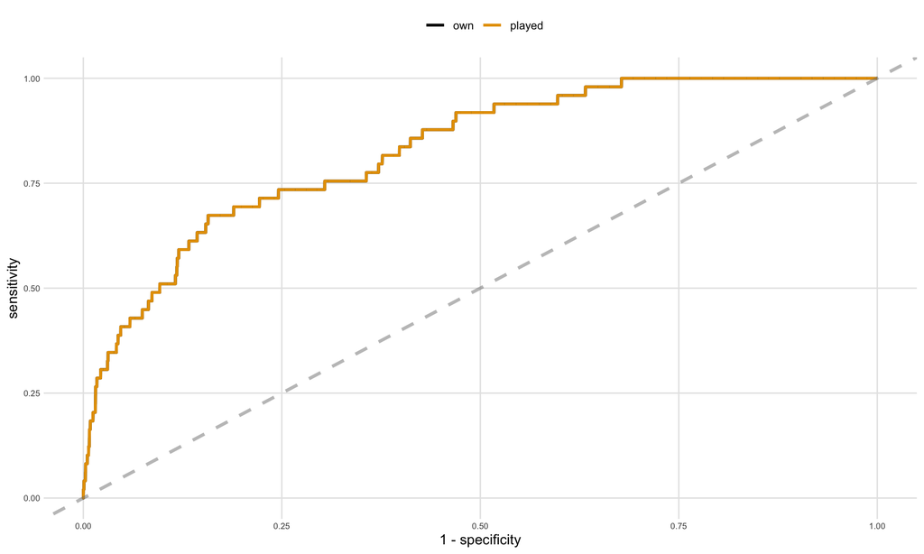

Another way to think about the model performance is to view its lift, or its ability to detect the positive outcomes over that of a null model. High lift indicates the model can much more quickly find all of the positive outcomes (in this case, games owned or played by the user), while a model with no lift is no better than random guessing.

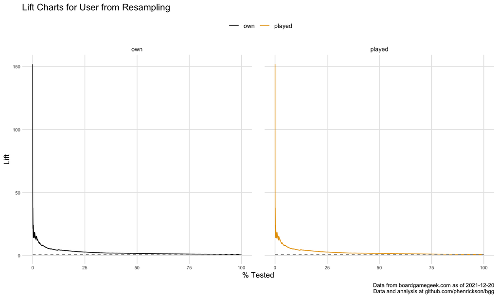

## 3.3 Most and Least Likely Games

What games does the model think SnowyAshton is **most likely to own** that are **not** in their collection?

| username | yearpublished | game_id | name | pred_own | actual_own |
| --- | --- | --- | --- | --- | --- |
| SnowyAshton | 1900 | 2136 | Pachisi | 0.47 | 0 |
| SnowyAshton | 1933 | 1406 | Monopoly | 0.46 | 0 |
| SnowyAshton | 2016 | 167791 | Terraforming Mars | 0.44 | 0 |
| SnowyAshton | 1900 | 45 | Perudo | 0.42 | 0 |
| SnowyAshton | 1990 | 120 | Hoity Toity | 0.39 | 0 |

What games does the model think SnowyAshton is **least likely to own** that **are** in their collection?

| username | yearpublished | game_id | name | pred_own | actual_own |
| --- | --- | --- | --- | --- | --- |
| SnowyAshton | 2011 | 84876 | The Castles of Burgundy | 0 | 1 |
| SnowyAshton | 2017 | 218603 | Photosynthesis | 0 | 1 |
| SnowyAshton | 2008 | 30549 | Pandemic | 0 | 1 |
| SnowyAshton | 2016 | 204583 | Kingdomino | 0 | 1 |
| SnowyAshton | 2019 | 276894 | Ticket to Ride: London | 0 | 1 |

## 3.4 Top Games by Year

Top 25 games most likely to be owned by the user in each year, highlighting in blue the games that the user has owned/played.

| rank | 2011 | 2012 | 2013 | 2014 | 2015 | 2016 | 2017 | 2018 | 2019 |
| --- | --- | --- | --- | --- | --- | --- | --- | --- | --- |
| 1 | Struggle for Catan | Terra Mystica | Legacy: The Testament of Duke de Crecy | Catan: Ancient Egypt | Exploding Kittens: NSFW Deck | Terraforming Mars | Gaia Project | Newton | Catan: Starfarers |
| 2 | The Ares Project | Catan: Family Edition | LEADERS: The Combined Strategy Game | Dragon Punch | Catan: Traveler – Compact Edition | Codenames: Pictures | Bears vs Babies | Underwater Cities | Era: Medieval Age |
| 3 | King of Tokyo | Star Trek: Catan | City of Remnants | Deception: Murder in Hong Kong | Through the Ages: A New Story of Civilization | Simon's Cat Card Game | Codenames: Marvel | Decrypto | Barrage |
| 4 | The Walking Dead: The Board Game | Monopoly Millionaire Deal Card Game | UGO! | Witness | I Hate Zombies | Fuji Flush | Codenames: Disney – Family Edition | 5-Minute Marvel | The Crew: The Quest for Planet Nine |
| 5 | Munchkin Axe Cop | Targi | Friese's Landlord | Star Realms | The Bloody Inn | Citadels | A Game of Thrones: Catan – Brotherhood of the Watch | Critical Mass: Raijin vs Archon | Letter Jam |
| 6 | Tem-Purr-A | Eight-Minute Empire | Funemployed | North Wind | Codenames | Crazy Karts | Codenames: Duet | Critical Mass: Patriot vs Iron Curtain | Tapestry |
| 7 | Nightfall | Neuroshima: Convoy | Hanamikoji | Catan Junior | Star Realms: Colony Wars | Kanagawa | Break the Code | Catan Histories: Rise of the Inkas | Watergate |
| 8 | Yomi | Fantastiqa: The Rucksack Edition | Theseus: The Dark Orbit | King of New York | Tumult Royale | Halt mal kurz: Das Känguru-Spiel | GYM | Monolith Arena | Unmatched: Battle of Legends, Volume One |
| 9 | Streams | Copycat | Eight-Minute Empire: Legends | Smash Up: Monster Smash | The Pursuit of Happiness | Exceed Fighting System | The Castles of Burgundy: The Dice Game | The Mind | Fiesta de los Muertos |
| 10 | Ninjato | Uchronia | 8 Masters' Revenge | Yomi (Second Edition) | 504 | 1572: The Lost Expedition | Exploding Kittens: Party Pack | Penny Papers Adventures: The Valley of Wiraqocha | Color Brain: Disney Edition |
| 11 | Discworld: Ankh-Morpork | Clash of Cultures | Corto | [redacted] | Tiny Epic Galaxies | Smugglers | Mountains of Madness | Scare It! | Crystal Palace |
| 12 | Takenoko | Penny Arcade: The Game – Rumble in R'lyeh | Welcome to the Dungeon | La Granja | The Game | Codenames: Deep Undercover | The Shipwreck Arcana | Micropolis | Village Pillage |
| 13 | Penny Arcade: The Game – Gamers vs. Evil | Waka Waka | Patchistory | Alchemists | TKO | Trivial Pursuit: Classic Edition | Gloomhaven | Nessos | Unmatched: Robin Hood vs. Bigfoot |
| 14 | Catan Histories: Merchants of Europe | Smash Up | Candy Chaser | Loopin' Chewie | Rolling America | Trivial Pursuit: 2000s | Munchkin X-Men | Warhammer Quest: Blackstone Fortress | Ishtar: Gardens of Babylon |
| 15 | Rumble in the House | Crazy Creatures of Dr. Gloom | Concept | Evolution | Far Space Foundry | Munchkin Marvel | Fast Forward: FORTRESS | Smash Up: That '70s Expansion | Maracaibo |
| 16 | Sentinels of the Multiverse | Love Letter | Impulse | Power Grid Deluxe: Europe/North America | Epic Card Game | OrganATTACK! | Fast Forward: FEAR | Duelosaur Island | Combo Fighter |
| 17 | A Few Acres of Snow | Mini Curling Game | Five Cucumbers | Onward to Venus | Love Letter: Batman | When I Dream | Smash Up: What Were We Thinking? | Smash Up: Oops, You Did It Again | Ringmaster: Welcome to the Big Top |
| 18 | The Blue Lion | Munchkin Conan | Ghooost! | Yardmaster Express | WWE Superstar Showdown | Teenage Mutant Ninja Turtles: Shadows of the Past | Bunny Kingdom | The Grimm Forest | Sherlock: Entre tumbas |
| 19 | Battleship: Hidden Threat | Pax Porfiriana | Spyrium | Smash Up: Science Fiction Double Feature | Holmes: Sherlock & Mycroft | Adrenaline | Dracula's Feast | Star Realms: Frontiers | Amul |
| 20 | Martian Dice | Antike Duellum | Risk: The Walking Dead – Survival Edition | Patchwork | Raptor | Smash Up: It's Your Fault! | Muse | The Grizzled: Armistice Edition | Tiny Towns |
| 21 | Dungeon Petz | Urbion | Tales & Games: The Three Little Pigs | Pack of Heroes | Vs System 2PCG: The Marvel Battles | 13 Days: The Cuban Missile Crisis | Itchy Feet: the Travel Game | Shards of Infinity | In the Hall of the Mountain King |
| 22 | Space Empires: 4X | Okiya | Invaders | Geek Out! Pop Culture Party | Risk: Europe | Word Slam | Ticket to Ride: Germany | Star Wars: Han Solo Card Game | Smash Up: World Tour – International Incident |
| 23 | Battleship Galaxies | Samurai Battles | Smash Up: Awesome Level 9000 | Lagoon: Land of Druids | The King Is Dead | Hit Z Road | Smash Up: Big in Japan | Sherlock: Last Call | TINYforming Mars |
| 24 | Wiraqocha | Star Trek Deck Building Game: The Next Generation – Next Phase | Smash Up: The Obligatory Cthulhu Set | DungeonQuest Revised Edition | Qwirkle Cards | Welcome Back to the Dungeon | Fog of Love | Sherlock: 13 Hostages | Marvel: Crisis Protocol |
| 25 | Shitenno | Suburbia | The Ravens of Thri Sahashri | Red7 | Bang! The Dice Game: The Walking Dead | The Mysterious Forest | The Game: Face to Face | First Contact | Terrors of London |

## 3.5 Interactive Predictions from Resampling

Interactive table for predictions from resampling.

|  | username | yearpublished | rank | game_id | name | pred_played | pred_own | actual_played | actual_own |
| --- | --- | --- | --- | --- | --- | --- | --- | --- | --- |
| 1 | SnowyAshton | 1900 | 2 | 2136 | Pachisi | 0.47 | 0.47 | 0 | 0 |
| 2 | SnowyAshton | 1900 | 5 | 45 | Perudo | 0.42 | 0.42 | 0 | 0 |
| 3 | SnowyAshton | 1900 | 10 | 10799 | Old Maid | 0.32 | 0.32 | 0 | 0 |
| 4 | SnowyAshton | 1900 | 12 | 2083 | Checkers | 0.22 | 0.22 | 0 | 0 |
| 5 | SnowyAshton | 1900 | 33 | 171 | Chess | 0.12 | 0.12 | 0 | 0 |
| 6 | SnowyAshton | 1900 | 45 | 17003 | Snap | 0.11 | 0.11 | 0 | 0 |
| 7 | SnowyAshton | 1900 | 53 | 7316 | Bingo | 0.09 | 0.09 | 1 | 1 |
| 8 | SnowyAshton | 1900 | 72 | 10789 | Pitch | 0.08 | 0.08 | 0 | 0 |
| 9 | SnowyAshton | 1900 | 78 | 15549 | Roulette | 0.08 | 0.08 | 0 | 0 |
| 10 | SnowyAshton | 1900 | 87 | 9851 | Shut the Box | 0.07 | 0.07 | 0 | 0 |

[output cut: 7426 more lines]

# 4 Validating the Model on 2020

How well did a model trained on a user’s collection through 2019 perform in predicting games for the user from 2020?

| username | outcome_type | yearpublished | .metric | .estimator | .estimate |
| --- | --- | --- | --- | --- | --- |
| SnowyAshton | own | 2020 | roc_auc | binary | 0.636 |
| SnowyAshton | played | 2020 | roc_auc | binary | 0.636 |

Table of top 25 games from 2020, highlighting games that the user owns.

| username | yearpublished | game_id | name | pred_own | pred_played | actual_own | actual_played |
| --- | --- | --- | --- | --- | --- | --- | --- |
| SnowyAshton | 2020 | 184267 | On Mars | 0.12 | 0.12 | 0 | 0 |
| SnowyAshton | 2020 | 320819 | Dinner in Paris | 0.07 | 0.07 | 0 | 0 |
| SnowyAshton | 2020 | 316927 | Sweet Existence: A Strange Planet Card Game | 0.06 | 0.06 | 0 | 0 |
| SnowyAshton | 2020 | 295577 | Dungeon Mayhem: Monster Madness | 0.05 | 0.05 | 0 | 0 |
| SnowyAshton | 2020 | 323367 | Outsmarted! | 0.05 | 0.05 | 0 | 0 |
| SnowyAshton | 2020 | 288513 | Tranquility | 0.04 | 0.04 | 0 | 0 |
| SnowyAshton | 2020 | 302840 | Carcata | 0.04 | 0.04 | 0 | 0 |
| SnowyAshton | 2020 | 245659 | Vampire: The Masquerade – Vendetta | 0.03 | 0.03 | 0 | 0 |
| SnowyAshton | 2020 | 256317 | Guild Master | 0.03 | 0.03 | 0 | 0 |
| SnowyAshton | 2020 | 294484 | Unmatched: Cobble & Fog | 0.03 | 0.03 | 0 | 0 |
| SnowyAshton | 2020 | 298047 | Marvel United | 0.03 | 0.03 | 0 | 0 |
| SnowyAshton | 2020 | 300322 | Hallertau | 0.03 | 0.03 | 0 | 0 |
| SnowyAshton | 2020 | 312786 | Poetry for Neanderthals | 0.03 | 0.03 | 0 | 0 |
| SnowyAshton | 2020 | 246900 | Eclipse: Second Dawn for the Galaxy | 0.02 | 0.02 | 0 | 0 |
| SnowyAshton | 2020 | 276205 | Philosophia: Dare to be Wise | 0.02 | 0.02 | 0 | 0 |
| SnowyAshton | 2020 | 291457 | Gloomhaven: Jaws of the Lion | 0.02 | 0.02 | 0 | 0 |
| SnowyAshton | 2020 | 292907 | The Deadlies | 0.02 | 0.02 | 0 | 0 |
| SnowyAshton | 2020 | 296498 | 10 Dice | 0.02 | 0.02 | 0 | 0 |
| SnowyAshton | 2020 | 297735 | Disciple Detective | 0.02 | 0.02 | 0 | 0 |
| SnowyAshton | 2020 | 299074 | Space Battle Lunchtime Card Game | 0.02 | 0.02 | 0 | 0 |
| SnowyAshton | 2020 | 299169 | Spicy | 0.02 | 0.02 | 0 | 0 |
| SnowyAshton | 2020 | 302193 | Wonder Woman: Challenge of the Amazons | 0.02 | 0.02 | 0 | 0 |
| SnowyAshton | 2020 | 302734 | Master Word | 0.02 | 0.02 | 0 | 0 |
| SnowyAshton | 2020 | 304285 | Infinity Gauntlet: A Love Letter Game | 0.02 | 0.02 | 0 | 0 |
| SnowyAshton | 2020 | 308765 | Praga Caput Regni | 0.02 | 0.02 | 0 | 0 |

# 5 Predicting Upcoming Games (2020 and On) for **SnowyAshton**

Examine the top games for the test set.

| username | yearpublished | game_id | name | rank | own | played |
| --- | --- | --- | --- | --- | --- | --- |
| SnowyAshton | 2020 | 184267 | On Mars | 1 | 0.12 | 0.12 |
| SnowyAshton | 2020 | 320819 | Dinner in Paris | 2 | 0.07 | 0.07 |
| SnowyAshton | 2020 | 316927 | Sweet Existence: A Strange Planet Card Game | 3 | 0.06 | 0.06 |
| SnowyAshton | 2020 | 295577 | Dungeon Mayhem: Monster Madness | 4 | 0.05 | 0.05 |
| SnowyAshton | 2020 | 323367 | Outsmarted! | 5 | 0.05 | 0.05 |
| SnowyAshton | 2020 | 302840 | Carcata | 6 | 0.04 | 0.04 |
| SnowyAshton | 2020 | 288513 | Tranquility | 7 | 0.04 | 0.04 |
| SnowyAshton | 2020 | 294484 | Unmatched: Cobble & Fog | 8 | 0.03 | 0.03 |
| SnowyAshton | 2020 | 298047 | Marvel United | 9 | 0.03 | 0.03 |
| SnowyAshton | 2020 | 312786 | Poetry for Neanderthals | 10 | 0.03 | 0.03 |
| SnowyAshton | 2020 | 245659 | Vampire: The Masquerade – Vendetta | 11 | 0.03 | 0.03 |
| SnowyAshton | 2020 | 256317 | Guild Master | 12 | 0.03 | 0.03 |
| SnowyAshton | 2020 | 300322 | Hallertau | 13 | 0.03 | 0.03 |
| SnowyAshton | 2020 | 310611 | Sherlock Far West: Disparos al amanecer | 14 | 0.02 | 0.02 |
| SnowyAshton | 2020 | 310610 | Sherlock Far West: La Mina Maldita | 15 | 0.02 | 0.02 |
| SnowyAshton | 2020 | 310612 | Sherlock Far West: Pacto con el diablo | 16 | 0.02 | 0.02 |
| SnowyAshton | 2020 | 325678 | Sherlock: Ensayos Fabianos | 17 | 0.02 | 0.02 |
| SnowyAshton | 2020 | 325681 | Sherlock: Asesinato en el Sind Mail | 18 | 0.02 | 0.02 |
| SnowyAshton | 2020 | 297735 | Disciple Detective | 19 | 0.02 | 0.02 |
| SnowyAshton | 2020 | 325679 | Sherlock: La copia | 20 | 0.02 | 0.02 |
| SnowyAshton | 2020 | 246900 | Eclipse: Second Dawn for the Galaxy | 21 | 0.02 | 0.02 |
| SnowyAshton | 2020 | 299169 | Spicy | 22 | 0.02 | 0.02 |
| SnowyAshton | 2020 | 311193 | Anno 1800 | 23 | 0.02 | 0.02 |
| SnowyAshton | 2020 | 302734 | Master Word | 24 | 0.02 | 0.02 |
| SnowyAshton | 2020 | 292907 | The Deadlies | 25 | 0.02 | 0.02 |
| SnowyAshton | 2021 | 324856 | The Crew: Mission Deep Sea | 1 | 0.08 | 0.08 |
| SnowyAshton | 2021 | 341164 | Exploding Minions | 2 | 0.05 | 0.05 |
| SnowyAshton | 2021 | 343905 | Boonlake | 3 | 0.05 | 0.05 |
| SnowyAshton | 2021 | 299684 | Khôra: Rise of an Empire | 4 | 0.04 | 0.04 |
| SnowyAshton | 2021 | 342942 | Ark Nova | 5 | 0.04 | 0.04 |
| SnowyAshton | 2021 | 326804 | Rorschach | 6 | 0.03 | 0.03 |
| SnowyAshton | 2021 | 298102 | Roll Camera!: The Filmmaking Board Game | 7 | 0.03 | 0.03 |
| SnowyAshton | 2021 | 310873 | Carnegie | 8 | 0.03 | 0.03 |
| SnowyAshton | 2021 | 336382 | Marvel United: X-Men | 9 | 0.03 | 0.03 |
| SnowyAshton | 2021 | 320446 | Corduba 27 a.C. | 10 | 0.03 | 0.03 |
| SnowyAshton | 2021 | 329839 | So Clover! | 11 | 0.02 | 0.02 |
| SnowyAshton | 2021 | 328569 | Mint Bid | 12 | 0.02 | 0.02 |
| SnowyAshton | 2021 | 336552 | Mystic Paths | 13 | 0.02 | 0.02 |
| SnowyAshton | 2021 | 328871 | Terraforming Mars: Ares Expedition | 14 | 0.02 | 0.02 |
| SnowyAshton | 2021 | 333553 | For the King (and Me) | 15 | 0.02 | 0.02 |
| SnowyAshton | 2021 | 284653 | Mind MGMT: The Psychic Espionage “Game.” | 16 | 0.02 | 0.02 |
| SnowyAshton | 2021 | 277469 | The Phantom: The Card Game | 17 | 0.02 | 0.02 |
| SnowyAshton | 2021 | 299566 | Batman: The Animated Series Adventures – Shadow of the Bat | 18 | 0.02 | 0.02 |
| SnowyAshton | 2021 | 290618 | Wishland | 19 | 0.02 | 0.02 |
| SnowyAshton | 2021 | 295535 | Dark Ages: Heritage of Charlemagne | 20 | 0.02 | 0.02 |
| SnowyAshton | 2021 | 304985 | Dark Ages: Holy Roman Empire | 21 | 0.02 | 0.02 |
| SnowyAshton | 2021 | 348955 | Rock Paper Scissors: Deluxe Edition | 22 | 0.02 | 0.02 |
| SnowyAshton | 2021 | 306697 | Smash Up: Marvel | 23 | 0.02 | 0.02 |
| SnowyAshton | 2021 | 266448 | Imperium: The Contention | 24 | 0.02 | 0.02 |
| SnowyAshton | 2021 | 327971 | Hippocrates | 25 | 0.02 | 0.02 |
| SnowyAshton | 2022 | 305096 | Endless Winter: Paleoamericans | 1 | 0.02 | 0.02 |
| SnowyAshton | 2022 | 293547 | Reload | 2 | 0.02 | 0.02 |
| SnowyAshton | 2022 | 295770 | Frosthaven | 3 | 0.02 | 0.02 |
| SnowyAshton | 2022 | 342246 | Feuding Foodies | 4 | 0.02 | 0.02 |
| SnowyAshton | 2022 | 343900 | Senjutsu: Battle For Japan | 5 | 0.01 | 0.01 |
| SnowyAshton | 2022 | 299594 | Megapulse | 6 | 0.01 | 0.01 |
| SnowyAshton | 2022 | 284118 | Mechanical Beast | 7 | 0.01 | 0.01 |
| SnowyAshton | 2022 | 240980 | Blood on the Clocktower | 8 | 0.01 | 0.01 |
| SnowyAshton | 2022 | 324090 | Scarface 1920 | 9 | 0.01 | 0.01 |
| SnowyAshton | 2022 | 334065 | Verdant | 10 | 0.01 | 0.01 |
| SnowyAshton | 2022 | 304051 | Creature Comforts | 11 | 0.01 | 0.01 |
| SnowyAshton | 2022 | 294529 | Entropia: The Game | 12 | 0.01 | 0.01 |
| SnowyAshton | 2022 | 339592 | Sheep in Disguise | 13 | 0.01 | 0.01 |
| SnowyAshton | 2022 | 280726 | Legacies | 14 | 0.01 | 0.01 |
| SnowyAshton | 2022 | 322589 | Zapotec | 15 | 0.01 | 0.01 |
| SnowyAshton | 2022 | 317511 | Tindaya | 16 | 0.01 | 0.01 |
| SnowyAshton | 2022 | 284189 | Foundations of Rome | 17 | 0.01 | 0.01 |
| SnowyAshton | 2022 | 258779 | Planet Unknown | 18 | 0.01 | 0.01 |
| SnowyAshton | 2022 | 260923 | Titan | 19 | 0.01 | 0.01 |
| SnowyAshton | 2022 | 295895 | Distilled | 20 | 0.01 | 0.01 |
| SnowyAshton | 2022 | 295374 | Long Shot: The Dice Game | 21 | 0.01 | 0.01 |
| SnowyAshton | 2022 | 330950 | Age of Galaxy | 22 | 0.01 | 0.01 |
| SnowyAshton | 2022 | 252315 | The Everrain | 23 | 0.00 | 0.00 |
| SnowyAshton | 2022 | 327711 | It's a Wonderful Kingdom | 24 | 0.00 | 0.00 |
| SnowyAshton | 2022 | 270871 | Agemonia | 25 | 0.00 | 0.00 |

## 5.1 Interactive Table for Upcoming Games 2020 and On

|  | username | yearpublished | game_id | name | rank | own | played |
| --- | --- | --- | --- | --- | --- | --- | --- |
| 1 | SnowyAshton | 2020 | 184267 | On Mars | 1 | 0.12 | 0.12 |
| 2 | SnowyAshton | 2021 | 324856 | The Crew: Mission Deep Sea | 2 | 0.08 | 0.08 |
| 3 | SnowyAshton | 2020 | 320819 | Dinner in Paris | 3 | 0.07 | 0.07 |
| 4 | SnowyAshton | 2020 | 316927 | Sweet Existence: A Strange Planet Card Game | 4 | 0.06 | 0.06 |
| 5 | SnowyAshton | 2021 | 341164 | Exploding Minions | 5 | 0.05 | 0.05 |
| 6 | SnowyAshton | 2020 | 295577 | Dungeon Mayhem: Monster Madness | 6 | 0.05 | 0.05 |
| 7 | SnowyAshton | 2021 | 343905 | Boonlake | 7 | 0.05 | 0.05 |
| 8 | SnowyAshton | 2020 | 323367 | Outsmarted! | 8 | 0.05 | 0.05 |
| 9 | SnowyAshton | 2021 | 299684 | Khôra: Rise of an Empire | 9 | 0.04 | 0.04 |
| 10 | SnowyAshton | 2020 | 302840 | Carcata | 10 | 0.04 | 0.04 |

[output cut: 1627 more lines]